# Homework 3

Pimawat Mingkwan

11/12/2019

## Question 1

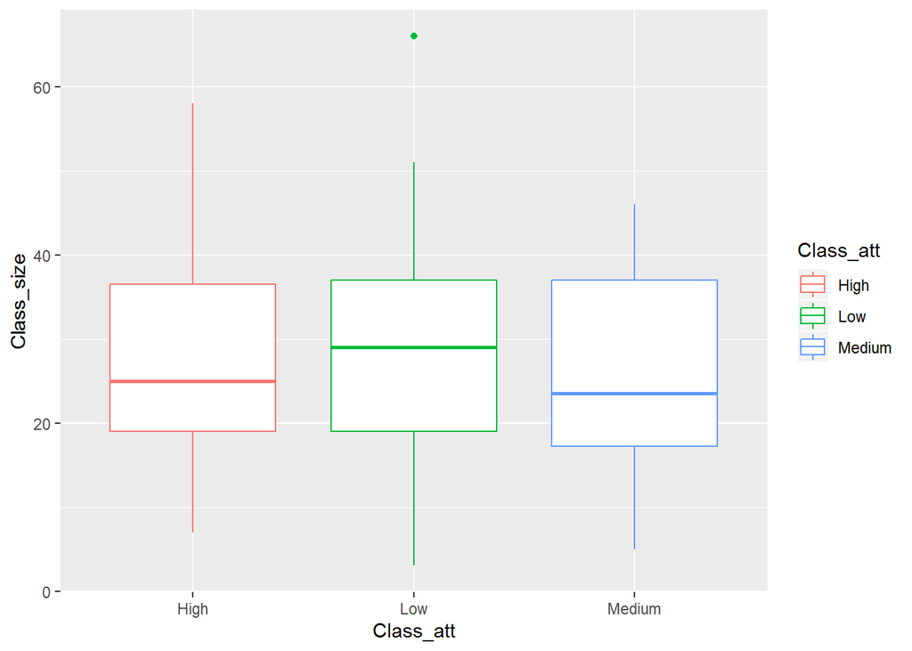

```r
mydat <- fread('tae.data')
mydata <- mydat

colnames(mydata) <- c("Native_Eng","Course_Ins","Course","Semester","Class_size","Class_att")

mydata.DT <- as.data.table(mydata)
mydata.DT$Native_Eng <- as.character(mydata.DT$Native_Eng)
mydata.DT[which(Native_Eng=='1'),]$Native_Eng <- "Eng"
mydata.DT[which(Native_Eng=='2'),]$Native_Eng <- "Non-Eng"

mydata.DT$Semester <- as.character(mydata.DT$Semester)
mydata.DT$Class_att <- as.character(mydata.DT$Class_att)
mydata.DT$Course_Ins <- as.character(mydata.DT$Course_Ins)
mydata.DT$Course <- as.character(mydata.DT$Course)
mydata.DT[which(Semester=='1'),]$Semester <- "Summer"
mydata.DT[which(Semester=='2'),]$Semester <- "Regular"
mydata.DT[which(Class_att=='1'),]$Class_att <- "Low"
mydata.DT[which(Class_att=='2'),]$Class_att <- "Medium"
mydata.DT[which(Class_att=='3'),]$Class_att <- "High"

mydata.DT$TA <- c(1:151)
mydata.DT$TA <- as.character(mydata.DT$TA)

ggplot(mydata.DT, aes(x=Class_att,y=Class_size,color = Class_att)) + geom_boxplot()
```

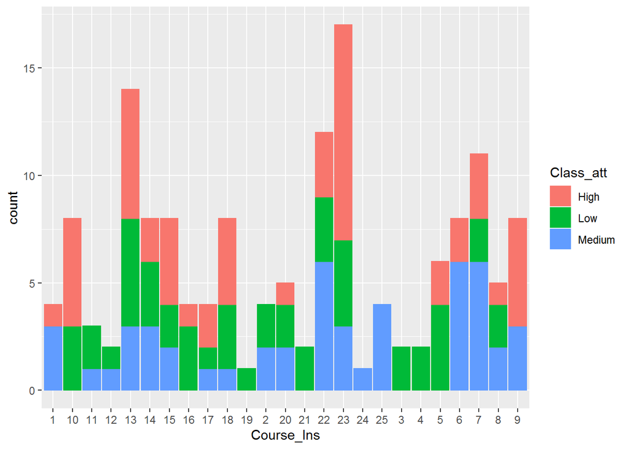

```r
ggplot(mydata.DT, aes(x=Course_Ins)) + geom_bar(aes(color = Class_att,fill = Class_att))
```

#From the graph we will see that instructors number 3,4,19,21 always evaluate class attribute at Low, and instructors number 1,6,9,24,25 never evaluate class attribute at Low.

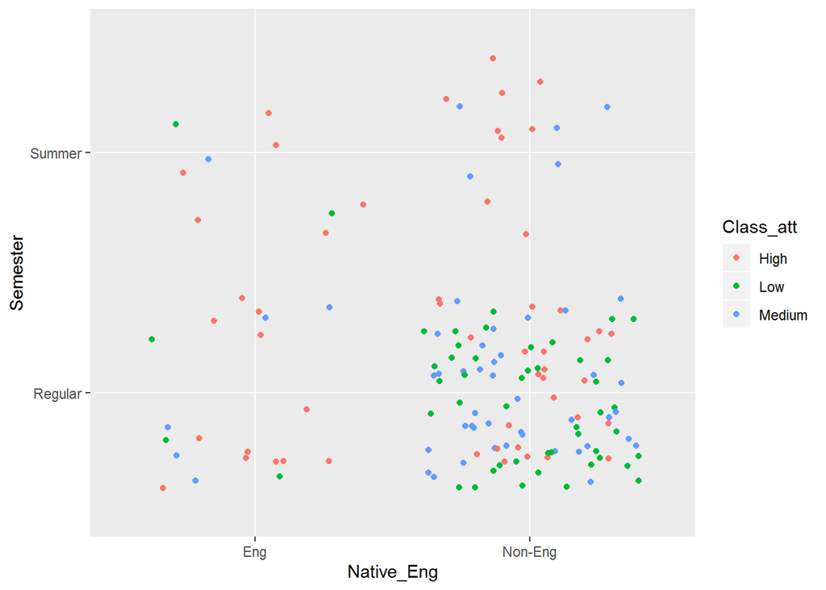

```r
ggplot(mydata.DT, aes(x=Native_Eng,y=Semester,color=Class_att)) + geom_jitter()
```

#Class at summer that teach by non native english is never get class attribute at Low.

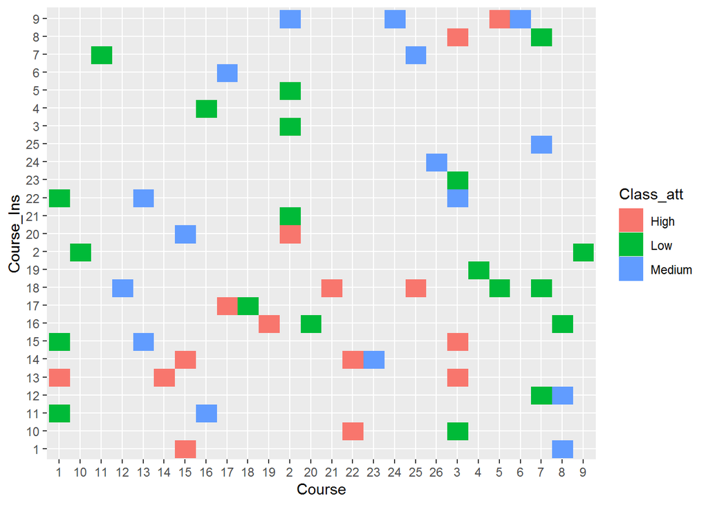

```r
ggplot(mydata.DT, aes(x=Course,y=Course_Ins,color=Class_att)) + geom_raster(aes(fill = Class_att))
```

## Question 2

```r
require(stringr)

multiCheat <- read.csv("multiCheat3.csv",header = T)
checkSol <- matrix(rep(0,300),ncol = 30)
multiCheat2 <- multiCheat

for (i in 2:31) {
  for (j in 2:11) {
   if(multiCheat[j,i]==multiCheat[1,i]){
     checkSol[j-1,i-1]<-1
   }
   else if(multiCheat[j,i]!=multiCheat[1,i]){
     checkSol[j-1,i-1]<-0
   }
  }
}

colnames(checkSol) <- colnames(multiCheat[,2:31])
rownames(checkSol) <- multiCheat[2:11,1]

pairList <- t(combn(10,2))

stdCompare <- as.data.frame(cbind(multiCheat2[pairList[,1]+1,1],
      multiCheat2[pairList[,2]+1,1]))
stdCompare$V1 <- multiCheat2[pairList[,1]+1,1]
stdCompare$V2 <- multiCheat2[pairList[,2]+1,1]

for(i in 1:nrow(pairList)){
  std1 <- pairList[i,1]
  std2 <- pairList[i,2]
  stdCompare$co11[i] <- length(which(checkSol[std1,]==1&checkSol[std2,]==1))
  stdCompare$co00[i] <- length(which(checkSol[std1,]==0&checkSol[std2,]==0))
  stdCompare$co01[i] <- length(which(checkSol[std1,]==0&checkSol[std2,]==1))
  stdCompare$co10[i] <- length(which(checkSol[std1,]==1&checkSol[std2,]==0))
  stdCompare$ans.sim.c[i] <- length(which(multiCheat2[std1+1,]==multiCheat2[std2+1,]&checkSol[std1,]==1))
  stdCompare$ans.sim.w[i] <- length(which(multiCheat2[std1+1,]==multiCheat2[std2+1,]&checkSol[std1,]==0))
  stdCompare$ans.sim.[i] <- length(which(multiCheat2[std1+1,]==multiCheat2[std2+1,]))

  temp <- rep(0,30)
  temp[which(checkSol[std1,] == checkSol[std2,])] <- 1
  tempString <- paste(temp,collapse = '')
  stdCompare$mxSim[i] <- max(str_count(str_split(tempString,'0')[[1]]))
}
stdCompare
```

```
##       V1     V2 co11 co00 co01 co10 ans.sim.c ans.sim.w ans.sim. mxSim
## 1  Stu-1  Stu-2   11    8    6    5         8         5       13     5
## 2  Stu-1  Stu-3   11    6    8    5         5         6       11     4
## 3  Stu-1  Stu-4    9    9    5    7         4         6       10     3
## 4  Stu-1  Stu-5   14    5    9    2         7         7       14     5
## 5  Stu-1  Stu-6   13    6    8    3         9         8       17     7
## 6  Stu-1  Stu-7   12    9    5    4         8         6       14     5
## 7  Stu-1  Stu-8   11    6    8    5         6         6       12     6
## 8  Stu-1  Stu-9   13    4   10    3         6         7       13     3
## 9  Stu-1 Stu-10   13    6    8    3         7         7       14     5
## 10 Stu-2  Stu-3   10    4    9    7         5         5       10     3
## 11 Stu-2  Stu-4   10    9    4    7         7         7       14     5
## 12 Stu-2  Stu-5   17    7    6    0        11        13       24     9
## 13 Stu-2  Stu-6   12    4    9    5         7         7       14     5
## 14 Stu-2  Stu-7   12    8    5    5        11         8       19     6
```

[output cut: 31 more lines]

#From the result we can notice that student 2-5,5-7 have most similar answers , So we can suspect that number 5 is a source and number 2,7 are copiers.

## Question 3

#a

```r
require(stringr)
require(dplyr)
require(data.table)

Encryption <- read.csv('Encryption.csv')
set.seed(13)
key <- as.vector(sample(LETTERS ,size=26,replace=F))
ENCRY_MSG <- as.character(Encryption[5,2][1])
encry_msg <- str_to_lower(as.character(Encryption[5,2][1]))
ENCRY_MSG_ENCODE <- encry_msg

DECRY_MSG <- as.character(Encryption[6,2][1])
decry_msg <- str_to_lower(as.character(Encryption[6,2][1]))

for (i in 1:26) {
   ENCRY_MSG_ENCODE <- str_replace_all(ENCRY_MSG_ENCODE,letters[i],key[i])
}
ENCRY_MSG_ENCODE
```

```
## [1] "VDM FXEKGVB LF MZPQZMMHQZP QI LZM LF VDM TLIV RQJMGB HMPXHJMJ QZIVQVKVMI VDXV AHLJKEM MZPQZMMHI XZJ DQPDGB MJKEXVMJ MZPQZMMHQZP AMHILZZMG FLH VDM ZXVQLZ FLH LSMH ZQZMVB BMXHI VDM MJKEXVQLZ DMHM FLEKIMI LZ VDM AHLJKEVQLZ LF DQPDGB EXAXCGM XZJ ELZIEQMZVQLKI PHXJKXVMI RDL EXZ IMHSM XI X AQGGXH …
```

#e

```r
COUNT_STR <- as.data.frame(LETTERS)
for (i in 1:26) {
   COUNT_STR$count[i] <- str_count(ENCRY_MSG_ENCODE,LETTERS[i])
}
COUNT_STR
```

```
##    LETTERS count
## 1        A     7
## 2        B    14
## 3        C     5
## 4        D    25
## 5        E    22
## 6        F    16
## 7        G    20
## 8        H    38
## 9        I    31
## 10       J    20
## 11       K    18
## 12       L    40
## 13       M    78
## 14       N     0
## 15       O     1
## 16       P    12
## 17       Q    46
## 18       R     5
## 19       S     5
## 20       T    10
## 21       U     1
## 22       V    48
## 23       W     0
## 24       X    39
## 25       Y     1
## 26       Z    50
```

```r
COUNT_STR_ARR <- COUNT_STR %>% arrange(-count)
str_count3 <- read.csv('str_count3.csv',header = T)

Match_letter <- as.data.frame(cbind(COUNT_STR_ARR[,1],str_count3[,1]))
colnames(Match_letter) <- c("str_freq","str_table_freq")
Match_letter$str_freq <- COUNT_STR_ARR[,1]
Match_letter$str_table_freq <- str_count3[,1]

encry_msg_encode <- str_to_lower(ENCRY_MSG_ENCODE)
ENCRY_DECODE_TEST <- str_to_lower(ENCRY_MSG_ENCODE)
for (i in 1:26) {
   ENCRY_DECODE_TEST <- str_replace_all(ENCRY_DECODE_TEST,str_to_lower(as.character(Match_letter[i,1])),as.character(Match_letter[i,2]))
}
ENCRY_DECODE_TEST
```

```
## [1] "AHE MNDCLAF IM ETYOTEESOTY OR ITE IM AHE WIRA BOUELF SEYNSUEU OTRAOACAER AHNA GSIUCDE ETYOTEESR NTU HOYHLF EUCDNAEU ETYOTEESOTY GESRITTEL MIS AHE TNAOIT MIS IVES TOTEAF FENSR AHE EUCDNAOIT HESE MIDCRER IT AHE GSIUCDAOIT IM HOYHLF DNGNPLE NTU DITRDOETAOICR YSNUCNAER BHI DNT RESVE NR N GOLLNS …
```

#c

```r
ENCRY_MSG <- as.character(Encryption[5,2][1])
encry_msg <- str_to_lower(as.character(Encryption[5,2][1]))
ENCRY_MSG_ENCODE2 <- encry_msg
key2 <- key
key3 <- key

ENCRY_MSG_ENCODE2_SPLIT <- str_split_fixed(ENCRY_MSG_ENCODE2,"",n=str_length(ENCRY_MSG_ENCODE2))
ENCRY_MSG_ENCODE2_SP <- ENCRY_MSG_ENCODE2_SPLIT

for (i in 1:length(ENCRY_MSG_ENCODE2_SPLIT)) {
  if(ENCRY_MSG_ENCODE2_SPLIT[i]!=" "){
    ENCRY_MSG_ENCODE2_SP[i] <- str_replace_all(ENCRY_MSG_ENCODE2_SP[i],ENCRY_MSG_ENCODE2_SP[i],key2[which(letters==ENCRY_MSG_ENCODE2_SP[i])])
  }
  key2 <- c(key2[2:26],key2[1])
}
#which(letters==ENCRY_MSG_ENCODE2_SP[2])
#key3 <- c(key3[2:26],key3[1])
ENCODE2 <- str_c(ENCRY_MSG_ENCODE2_SP,sep = "", collapse ="" )
ENCODE2
```

```
## [1] "VQP WFQCVEQ XI VJYXPBNZFGF WK IIO RL MVH CMWG UJNCWY IPWMRWGG IBMPRQOORG LJYH AIUPBDO TRUVNHIPQ IPY JFMPGN DDNQDCZZ UXKYJSROEQE ZJHVUUHWH ZYC FKI JHGCQQ ETU AYDS VASZJW GIADW TCN CCVECSGII LTXL HCUWQSO QQ UFJ UVHDNQXUYY XI RBYNMI BYZNCTP MIW OYYJLSIEWNPZT ELBEKCSDR ELR TGN PVDTR KZ Y LQTZJS …
```

#d

```r
DECRY_MSG <- as.character(Encryption[6,2][1])
decry_msg <- str_to_lower(as.character(Encryption[6,2][1]))
decry_msg_en <- str_to_lower(as.character(Encryption[6,2][1]))
key2 <- key

key2 <- read.csv("book1.csv",header = T)
key2 <- colnames(key2)

decry_msg_en_split <- str_split_fixed(decry_msg_en,"",n=str_length(decry_msg_en))
decry_msg_en_sp <- decry_msg_en_split

for (i in 1:length(decry_msg_en_sp)) {
  if(decry_msg_en_sp[i]!="_"){
    decry_msg_en_sp[i] <- str_replace_all(decry_msg_en_sp[i],decry_msg_en_sp[i],
                                        LETTERS[which(str_to_lower(key2)==decry_msg_en_sp[i])])
  }
  key2 <- c(key2[2:26],key2[1])
}

DECODE2 <- str_c(decry_msg_en_sp,sep = "", collapse ="" )
DECODE2
```

```
## [1] "PERSEVERANCE_IS_A_GREAT_ELEMENT_OF_SUCCESS_IF_YOU_ONLY_KNOCK_LONG_ENOUGH_AND_LOUD_ENOUGH_AT_THE_GATE_YOU_ARE_SURE_TO_WAKE_UP_SOMEBODY"
```

#b Fequency analysis : we will count all letters appear in the qoute and compare with table of fequency letters such as in the table E is the most popular , so the most popular letter in the qoute is E.

## Question 4

#a clean up list 1. missing value - in Attribute : NA -> “null” - in Sales : NA -> estimate by equal the last period

2. duplicated Dress_ID : delete the row that duplicated and keep the first row.
3. typo
- Price : high -> High , low -> Low
- Style : sexy -> Sexy
- Size : s,small -> S
- Season : Automn -> Autumn , spring -> Spring , summer -> Summer , winter -> Winter
- Neckline : sweetheart -> Sweetheart
- etc.

```r
Attribute_DataSet2.Raw <- read.csv("Attribute DataSet2.csv",header = T)
Dress_Sales2.Raw <- read.csv("Dress Sales2.csv",header = T)

set.seed(13)
smpl <- sample(1:nrow(Attribute_DataSet2.Raw),450)
Attribute_DataSet2 <- Attribute_DataSet2.Raw[smpl,]
Attribute_DataSet2.Test <- Attribute_DataSet2.Raw[-smpl,]

Dup <- which(duplicated(Attribute_DataSet2$Dress_ID))
Attribute_DataSet2 <- Attribute_DataSet2[-Dup,]

Dup <- which(duplicated(Dress_Sales2.Raw$Dress_ID))
Dress_Sales2 <- Dress_Sales2.Raw[-Dup,]

##clean up Attr

Attribute_DataSet2.DT <- as.data.table(Attribute_DataSet2)
Attribute_DataSet2.DT[Price=="",]$Price <- "Average"
Attribute_DataSet2.DT[Price=="high",]$Price <- "High"
Attribute_DataSet2.DT[Price=="low",]$Price <- "Low"

Attribute_DataSet2.DT[Style=="sexy",]$Style <- "Sexy"

Attribute_DataSet2.DT[Size=="s",]$Size <- "S"
Attribute_DataSet2.DT[Size=="small",]$Size <- "S"

Attribute_DataSet2.DT[Season=="summer",]$Season <- "Summer"
Attribute_DataSet2.DT[Season=="spring",]$Season <- "Spring"
Attribute_DataSet2.DT[Season=="Automn",]$Season <- "Autumn"
Attribute_DataSet2.DT[Season=="winter",]$Season <- "Winter"
Attribute_DataSet2.DT[Season=="",]$Season <- "Autumn"

Attribute_DataSet2.DT[NeckLine=="",]$NeckLine <- "NULL"
Attribute_DataSet2.DT[NeckLine=="sweetheart",]$NeckLine <- "Sweetheart"

Attribute_DataSet2.DT[SleeveLength=="cap-sleeves",]$SleeveLength <- "capsleeves"
Attribute_DataSet2.DT[SleeveLength=="half",]$SleeveLength <- "halfsleeve"
Attribute_DataSet2.DT[SleeveLength=="sleeevless",]$SleeveLength <- "sleevless"
Attribute_DataSet2.DT[SleeveLength=="sleeveless",]$SleeveLength <- "sleevless"
Attribute_DataSet2.DT[SleeveLength=="sleveless",]$SleeveLength <- "sleevless"
Attribute_DataSet2.DT[SleeveLength=="threequater",]$SleeveLength <- "threequarter"
Attribute_DataSet2.DT[SleeveLength=="thressqatar",]$SleeveLength <- "threequarter"
Attribute_DataSet2.DT[SleeveLength=="urndowncollor",]$SleeveLength <- "turndowncollor"

Attribute_DataSet2.DT[waiseline=="",]$waiseline <- "null"

Attribute_DataSet2.DT[Material=="",]$Material <- "null"
Attribute_DataSet2.DT[Material=="modal",]$Material <- "model"
Attribute_DataSet2.DT[Material=="sill",]$Material <- "silk"

Attribute_DataSet2.DT[FabricType=="",]$FabricType <- "null"
Attribute_DataSet2.DT[FabricType=="flannael",]$FabricType <- "flannel"
Attribute_DataSet2.DT[FabricType=="knitted",]$FabricType <- "knitting"
Attribute_DataSet2.DT[FabricType=="satin",]$FabricType <- "sattin"
Attribute_DataSet2.DT[FabricType=="woolen",]$FabricType <- "wollen"
Attribute_DataSet2.DT[FabricType=="shiffon",]$FabricType <- "chiffon"

Attribute_DataSet2.DT[Decoration=="",]$Decoration <- "null"
Attribute_DataSet2.DT[Decoration=="none",]$Decoration <- "null"

Attribute_DataSet2.DT[Pattern.Type=="none",]$Pattern.Type <- "null"
Attribute_DataSet2.DT[Pattern.Type=="",]$Pattern.Type <- "null"
Attribute_DataSet2.DT[Pattern.Type=="leapord",]$Pattern.Type <- "leopard"
```

#b

```r
Dress_Sales2.DT <- as.data.table(Dress_Sales2.Raw[,1:24])
Dress_Sales2.DT.clean <- as.data.frame(Dress_Sales2.DT)

for (j in 2:ncol(Dress_Sales2.DT.clean)) {
  for (i in 1:nrow(Dress_Sales2.DT.clean)) {
    if(is.na(Dress_Sales2.DT.clean[i,j])){
      Dress_Sales2.DT.clean[i,j] <- Dress_Sales2.DT.clean[i,j-1]
    }
    else if(Dress_Sales2.DT.clean[i,j]=="Removed"||Dress_Sales2.DT.clean[i,j]=="removed"){
      Dress_Sales2.DT.clean[i,j] <- Dress_Sales2.DT.clean[i,j-1]
    }
    else if(Dress_Sales2.DT.clean[i,j]=="Orders"){
      Dress_Sales2.DT.clean[i,j] <- Dress_Sales2.DT.clean[i,j-1]
    }
  }
}
Dress_Sales2.DT.clean <- na.omit(Dress_Sales2.DT.clean)

Att.Sale <- Attribute_DataSet2.DT[Dress_Sales2.DT.clean,on=.(Dress_ID==Dress_ID)]
Att.Sale <- na.omit(Att.Sale)

Att.Sale.DT <- as.data.table(Att.Sale)
Att.Sale.DT$ X12.9.2013 <- as.numeric(as.character(Att.Sale.DT$ X12.9.2013))
Att.Sale.DT$ X14.9.2013 <- as.numeric(as.character(Att.Sale.DT$ X14.9.2013))
Att.Sale.DT$ X16.9.2013 <- as.numeric(as.character(Att.Sale.DT$ X16.9.2013))
Att.Sale.DT$ X18.9.2013 <- as.numeric(as.character(Att.Sale.DT$ X18.9.2013))
Att.Sale.DT$ X20.9.2013 <- as.numeric(as.character(Att.Sale.DT$ X20.9.2013))
Att.Sale.DT$ X22.9.2013 <- as.numeric(as.character(Att.Sale.DT$ X22.9.2013))

Att.Sale.DT.sale <- cbind(Att.Sale.DT[,1],Att.Sale.DT[,15:37])
Att.Sale.DT.rec <- Att.Sale.DT[Recommendation==1,]
Att.Sale.DT.rec.sale <- cbind(Att.Sale.DT.rec[,1],Att.Sale.DT.rec[,15:37])
Att.Sale.DT.rec.sale.sum <- apply(Att.Sale.DT.rec.sale[,2:24],2,sum)

test <- t(Att.Sale.DT.rec.sale.sum)

print(ts(test[1:23], frequency = 15, start = c(8, 14)),calendar = T)
```

```
##       p1    p2    p3    p4    p5    p6    p7    p8    p9   p10   p11   p12
## 8
## 9  42050 56209 57048 59119 59732 62100 64068 64203 65266 66695 69038 68436
## 10 71685 72058 74853 75028 75455 77916
##      p13   p14   p15
## 8        37167 39384
## 9  69010 71201 71302
## 10
```

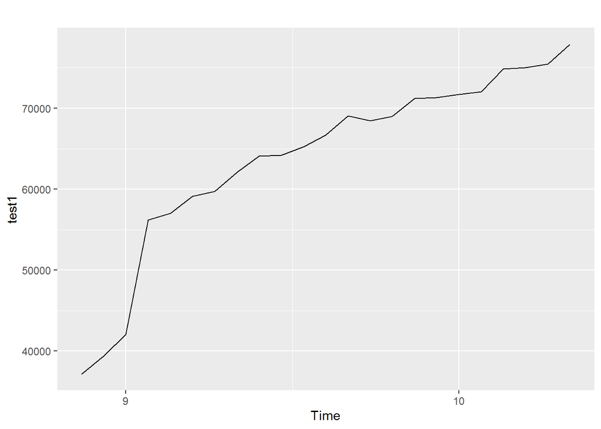

```r
test1 <- ts(test[1:23], frequency = 15, start = c(8, 14))
autoplot(test1)
```

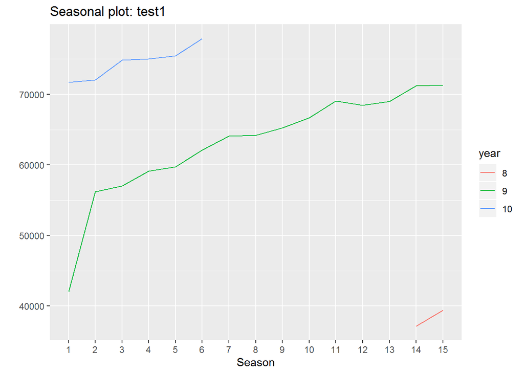

```r
ggseasonplot(test1)
```

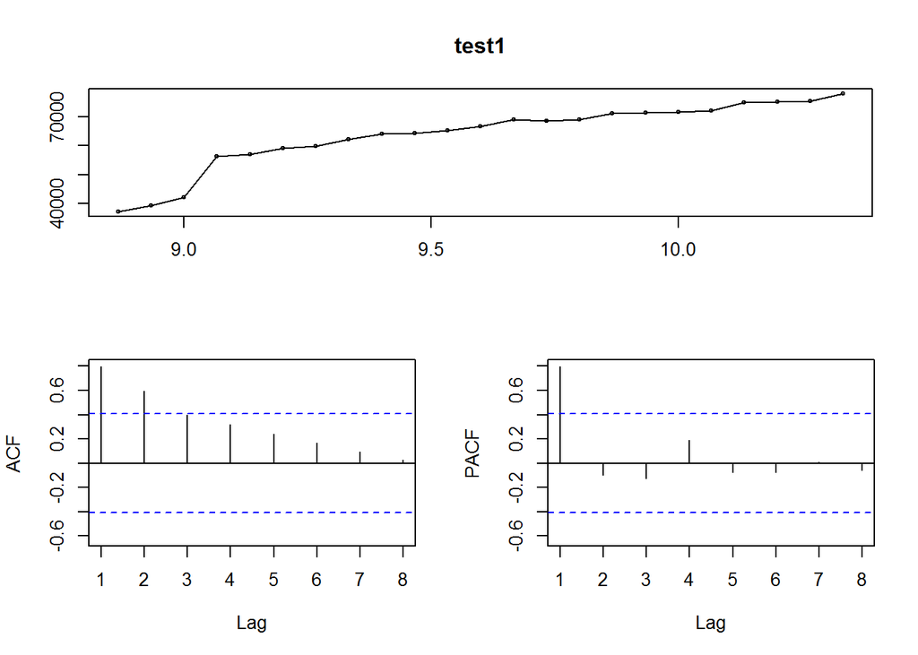

```r
tsdisplay(test1)
```

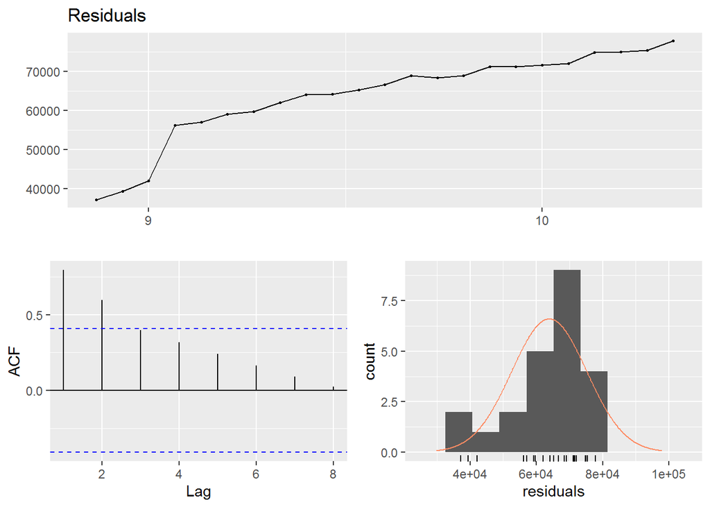

```r
checkresiduals(test1)
```

the sales of recommended dress is continuous increasing.

#c

```r
Att.Sale.DT2 <- mutate(Att.Sale.DT,Sum_sales = apply(Att.Sale.DT[,15:37],1,sum))
total.sale <- sum(Att.Sale.DT2[,38])

Att.Sale.DT2 %>% group_by(Style) %>% summarise(Sum_sales2 = sum(Sum_sales),Percent_sales = (sum(Sum_sales)/total.sale)*100)
```

```
## # A tibble: 12 x 3
##    Style    Sum_sales2 Percent_sales
##    <fct>         <dbl>         <dbl>
##  1 bohemian     103502        2.90
##  2 Brief         94786        2.65
##  3 Casual      1592692       44.6
##  4 cute         514820       14.4
##  5 fashion         581        0.0163
##  6 Flare          3336        0.0933
##  7 Novelty       23150        0.648
##  8 OL              429        0.0120
##  9 party        177831        4.98
## 10 Sexy         676496       18.9
## 11 vintage      253844        7.10
## 12 work         132358        3.70
```

```r
Att.Sale.DT2 %>% group_by(Price) %>% summarise(Sum_sales2 = sum(Sum_sales),Percent_sales = (sum(Sum_sales)/total.sale)*100)
```

```
## # A tibble: 5 x 3
##   Price     Sum_sales2 Percent_sales
##   <fct>          <dbl>         <dbl>
## 1 Average      1790965        50.1
## 2 High           87440         2.45
## 3 Low          1554382        43.5
## 4 Medium        114514         3.20
## 5 very-high      26524         0.742
```

```r
Att.Sale.DT2 %>% group_by(Season) %>% summarise(Sum_sales2 = sum(Sum_sales),Percent_sales = (sum(Sum_sales)/total.sale)*100)
```

```
## # A tibble: 4 x 3
##   Season Sum_sales2 Percent_sales
##   <fct>       <dbl>         <dbl>
## 1 Autumn     487600          13.6
## 2 Spring    1174675          32.9
## 3 Summer    1102533          30.9
## 4 Winter     809017          22.6
```

```r
Att.Sale.DT2 %>% group_by(NeckLine) %>% summarise(Sum_sales2 = sum(Sum_sales),Percent_sales = (sum(Sum_sales)/total.sale)*100)
```

```
## # A tibble: 16 x 3
##    NeckLine        Sum_sales2 Percent_sales
##    <fct>                <dbl>         <dbl>
##  1 backless              4184        0.117
##  2 boat-neck            69000        1.93
##  3 bowneck              32157        0.900
##  4 halter                3446        0.0964
##  5 mandarin-collor        429        0.0120
##  6 NULL                 26177        0.732
##  7 o-neck             2217418       62.0
##  8 open                 10237        0.286
##  9 peterpan-collor      25474        0.713
## 10 ruffled             155927        4.36
## 11 Scoop                 4634        0.130
## 12 slash-neck           88083        2.46
## 13 sqare-collor         46147        1.29
## 14 Sweetheart           27951        0.782
## 15 turndowncollor       96468        2.70
## 16 v-neck              766093       21.4
```

```r
Att.Sale.DT2 %>% group_by(SleeveLength) %>% summarise(Sum_sales2 = sum(Sum_sales),Percent_sales = (sum(Sum_sales)/total.sale)*100)
```

```
## # A tibble: 10 x 3
##    SleeveLength   Sum_sales2 Percent_sales
##    <fct>               <dbl>         <dbl>
##  1 butterfly           44077         1.23
##  2 capsleeves          26139         0.731
##  3 full               628921        17.6
##  4 halfsleeve         255530         7.15
##  5 NULL                13399         0.375
##  6 Petal               52256         1.46
##  7 short              923995        25.9
##  8 sleevless         1266823        35.4
##  9 threequarter       356983         9.99
## 10 turndowncollor       5702         0.160
```

```r
Att.Sale.DT2 %>% group_by(Material) %>% summarise(Sum_sales2 = sum(Sum_sales),Percent_sales = (sum(Sum_sales)/total.sale)*100)
```

```
## # A tibble: 21 x 3
##    Material      Sum_sales2 Percent_sales
##    <fct>              <dbl>         <dbl>
##  1 acrylic            17422         0.487
##  2 cashmere            8081         0.226
##  3 chiffonfabric     464493        13.0
##  4 cotton            985436        27.6
##  5 lace                8644         0.242
##  6 linen              28644         0.801
##  7 lycra              18303         0.512
##  8 microfiber         53889         1.51
##  9 milksilk           47900         1.34
## 10 mix               105041         2.94
## # ... with 11 more rows
```

```r
Att.Sale.DT2 %>% group_by(FabricType) %>% summarise(Sum_sales2 = sum(Sum_sales),Percent_sales = (sum(Sum_sales)/total.sale)*100)
```

```
## # A tibble: 18 x 3
##    FabricType Sum_sales2 Percent_sales
##    <fct>           <dbl>         <dbl>
##  1 batik            6562       0.184
##  2 broadcloth     186914       5.23
##  3 chiffon       1389093      38.9
##  4 Corduroy        15964       0.447
##  5 dobby            7353       0.206
##  6 flannel         30114       0.843
##  7 jersey         136876       3.83
##  8 knitting           77       0.00215
##  9 lace             3027       0.0847
## 10 null          1647220      46.1
## 11 organza          1092       0.0306
## 12 other            2319       0.0649
## 13 poplin           2082       0.0583
## 14 sattin          33167       0.928
## 15 terry             552       0.0154
## 16 tulle            3049       0.0853
## 17 wollen           4150       0.116
## 18 worsted        104214       2.92
```

```r
Att.Sale.DT2 %>% group_by(Decoration) %>% summarise(Sum_sales2 = sum(Sum_sales),Percent_sales = (sum(Sum_sales)/total.sale)*100)
```

```
## # A tibble: 24 x 3
##    Decoration Sum_sales2 Percent_sales
##    <fct>           <dbl>         <dbl>
##  1 applique       103418       2.89
##  2 beading         72543       2.03
##  3 bow            319707       8.95
##  4 button          36281       1.02
##  5 cascading         317       0.00887
##  6 crystal          9417       0.263
##  7 draped           9715       0.272
##  8 embroidary      61859       1.73
##  9 feathers           98       0.00274
## 10 flowers          9665       0.270
## # ... with 14 more rows
```

```r
Att.Sale.DT2 %>% group_by(Pattern.Type) %>% summarise(Sum_sales2 = sum(Sum_sales),Percent_sales = (sum(Sum_sales)/total.sale)*100)
```

```
## # A tibble: 13 x 3
##    Pattern.Type Sum_sales2 Percent_sales
##    <fct>             <dbl>         <dbl>
##  1 animal           294245        8.23
##  2 character          5541        0.155
##  3 dot              338116        9.46
##  4 floral            15153        0.424
##  5 geometric        155784        4.36
##  6 leopard           22220        0.622
##  7 null             415574       11.6
##  8 patchwork        238635        6.68
##  9 plaid              1496        0.0419
## 10 print            613538       17.2
## 11 solid           1362261       38.1
## 12 splice            16063        0.449
## 13 striped           95199        2.66
```

From the table we will see that which style,Price,Neckline,etc. is the most popular in each group.

#d

```r
require(corrplot)

princomp(Att.Sale.DT[,15:37])
```

```
## Call:
## princomp(x = Att.Sale.DT[, 15:37])
##
## Standard deviations:
##      Comp.1      Comp.2      Comp.3      Comp.4      Comp.5      Comp.6
## 2951.550288  524.121508  243.514123   73.307876   51.905819   48.532201
##      Comp.7      Comp.8      Comp.9     Comp.10     Comp.11     Comp.12
##   32.797224   30.528203   24.384265   20.493606   19.419519   12.499688
##     Comp.13     Comp.14     Comp.15     Comp.16     Comp.17     Comp.18
##   11.871844    8.808948    8.130009    6.438005    5.538889    3.690857
##     Comp.19     Comp.20     Comp.21     Comp.22     Comp.23
##    2.645582    2.448740    1.983619    1.648680    1.047032
##
##  23  variables and  455 observations.
```

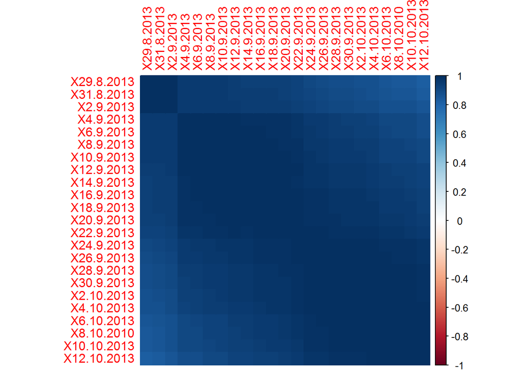

```r
corrplot(cor(Att.Sale.DT[,15:37]),method = "color")
```

this graph will show the correlation between each period and we can notice that if it far the correlation will decrease.

#e

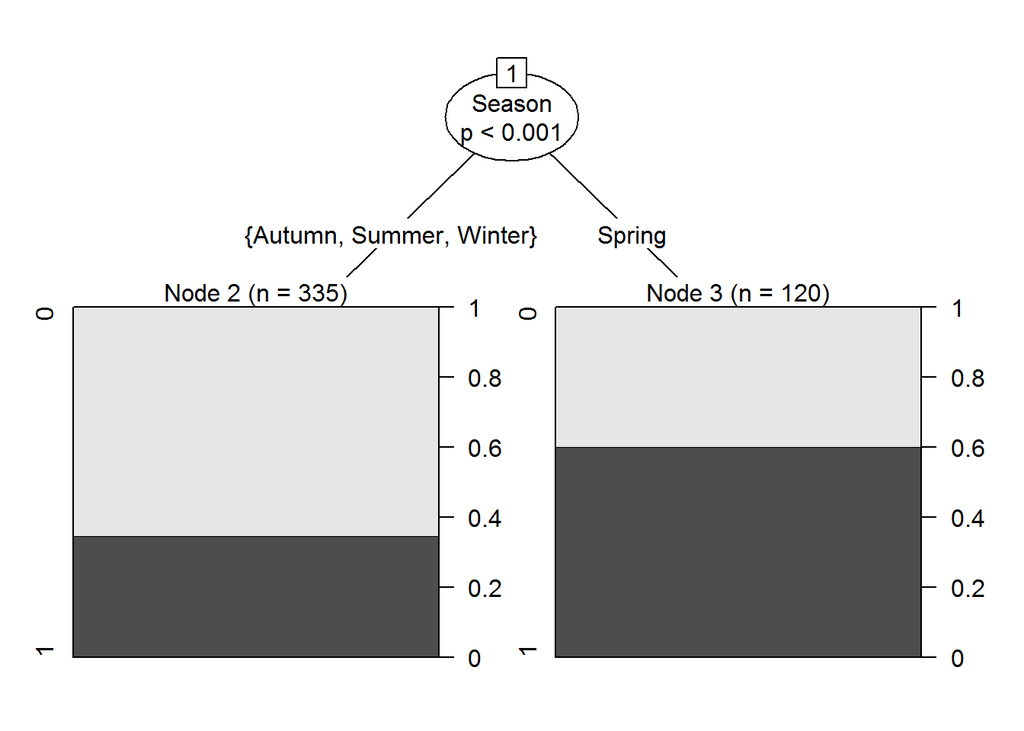

```r
require(class)

Att.Sale.DT.cha <- Att.Sale.DT
Att.Sale.DT.cha$Recommendation <- as.factor(Att.Sale.DT.cha$Recommendation)
Attribute_DataSet2.Test.cha <- Attribute_DataSet2.Test
Attribute_DataSet2.Test.cha$Recommendation <- as.factor(Attribute_DataSet2.Test.cha$Recommendation)

AS.ctree <- party::ctree(Recommendation~.,data=Att.Sale.DT.cha[,2:14])  #creating model , ~. : use all data
plot(AS.ctree)
```

```r
ctree.result <- predict(AS.ctree,newdata = Attribute_DataSet2.Test.cha[2:13])
table(ctree.result,Attribute_DataSet2.Test.cha[,14])
```

```
##
## ctree.result  0  1
##            0 29 15
##            1  1  5
```

```r
require(rpart)
AS.rpart <- rpart(Recommendation~.,data=Att.Sale.DT.cha[,2:14])
AS.result <- predict(AS.rpart,newdata = Attribute_DataSet2.Test.cha[2:13])
AS.result2 <- mutate(as.data.frame(AS.result),ans=0)
for (i in 1:nrow(AS.result2)) {
  if(AS.result2$`0`[i]<AS.result2$`1`[i]){
    AS.result2$ans[i] <- 1
  }
}

table(AS.result2$ans,Attribute_DataSet2.Test.cha[,14])
```

```
##
##      0  1
##   0 23 10
##   1  7 10
```

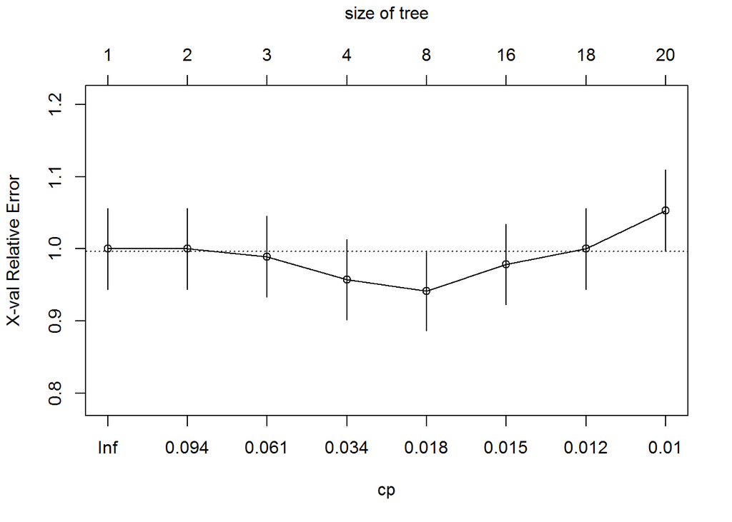

```r
plotcp(AS.rpart)
```

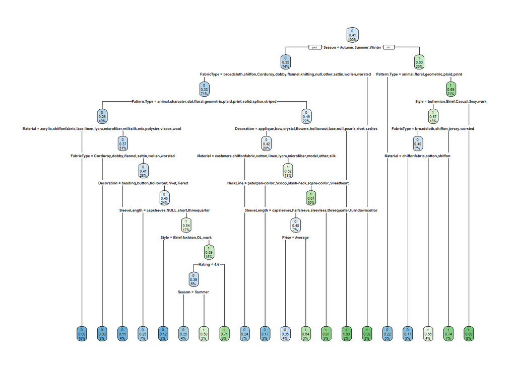

```r
require(rpart.plot)
rpart.plot(AS.rpart)
```

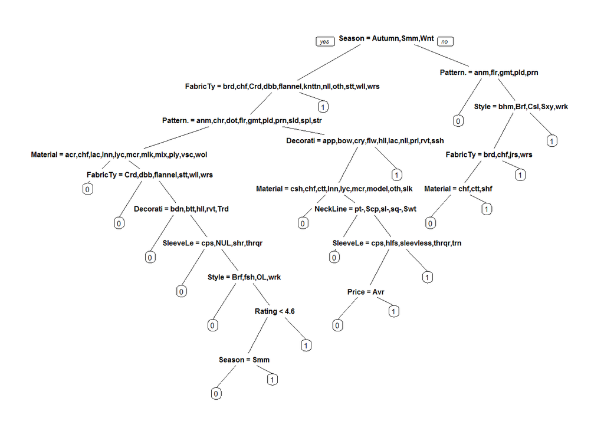

```r
rpart.plot::prp(AS.rpart)
```

```r
require(caret)
require(e1071)
AS.svm <- e1071::svm(Recommendation~.,data=Att.Sale.DT.cha[,2:14],kernel="linear") ##scale : ex. kg , g
SVM.result <- predict(AS.svm,newdata = Attribute_DataSet2.Test.cha[2:13])
table(SVM.result,Attribute_DataSet2.Test.cha[,14])
```

```
##
## SVM.result  0  1
##          0 24 15
##          1  6  5
```

```r
require(randomForest)
AS.rFore <- randomForest(Recommendation~.,data=Att.Sale.DT.cha[,2:14],ntree=1000) ## default = 500 trees
randFor.result <- predict(AS.rFore,newdata = Attribute_DataSet2.Test.cha[2:13])
importance(AS.rFore) ## importance of factors
```

```
##              MeanDecreaseGini
## Style               22.455083
## Price               13.967052
## Rating              17.899675
## Size                13.243123
## Season              16.972303
## NeckLine            18.510305
## SleeveLength        15.950096
## waiseline            8.637089
## Material            24.373440
## FabricType          16.577393
## Decoration          26.220542
## Pattern.Type        21.440426
```

```r
table(randFor.result,Attribute_DataSet2.Test.cha[,14])
```

```
##
## randFor.result  0  1
##              0 14  6
##              1 16 14
```

From the experiment we found that decision by ctree method provide the most corrected with 34 from 50.

#f

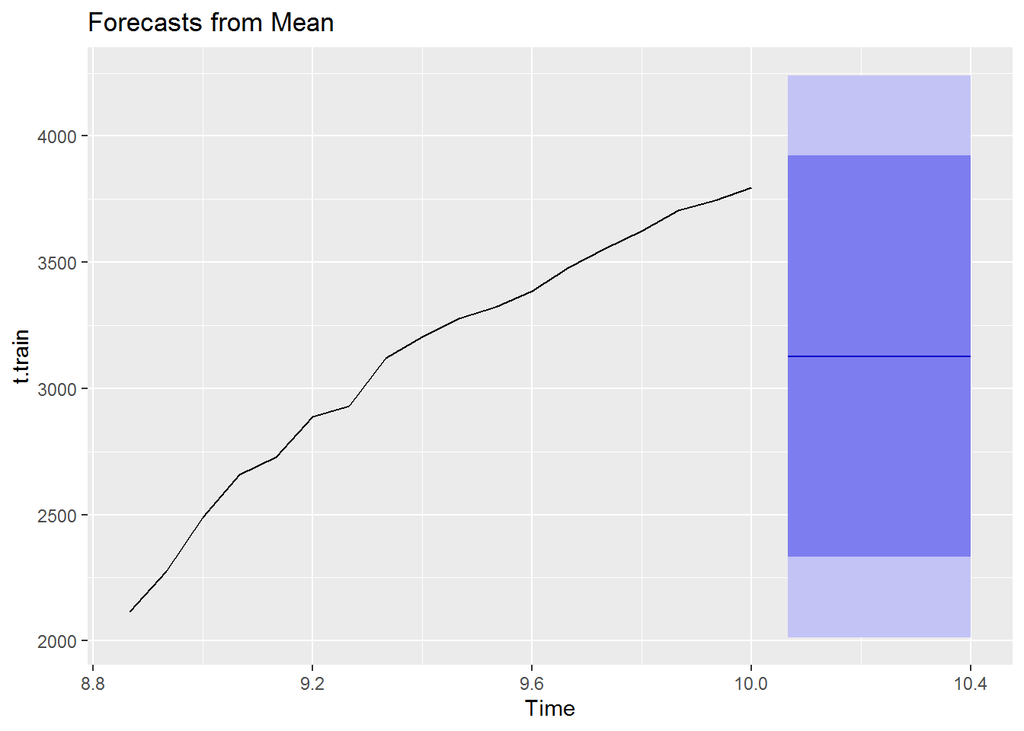

```r
t <- ts(t(Att.Sale.DT[1,15:37]), frequency = 15, start = c(8, 14))
t.train <- window(t,start=8,end=10)
t.test <- window(t,start=10,end=11)

t.meanf <- meanf(t.train,h=6,level = c(85,95))
autoplot(t.meanf)
```

```r
accuracy(t.meanf$mean,t.test)
```

```
##                ME     RMSE      MAE      MPE     MAPE      ACF1 Theil's U
## Test set 809.5556 812.9387 809.5556 20.53467 20.53467 0.3430737  14.83749
```

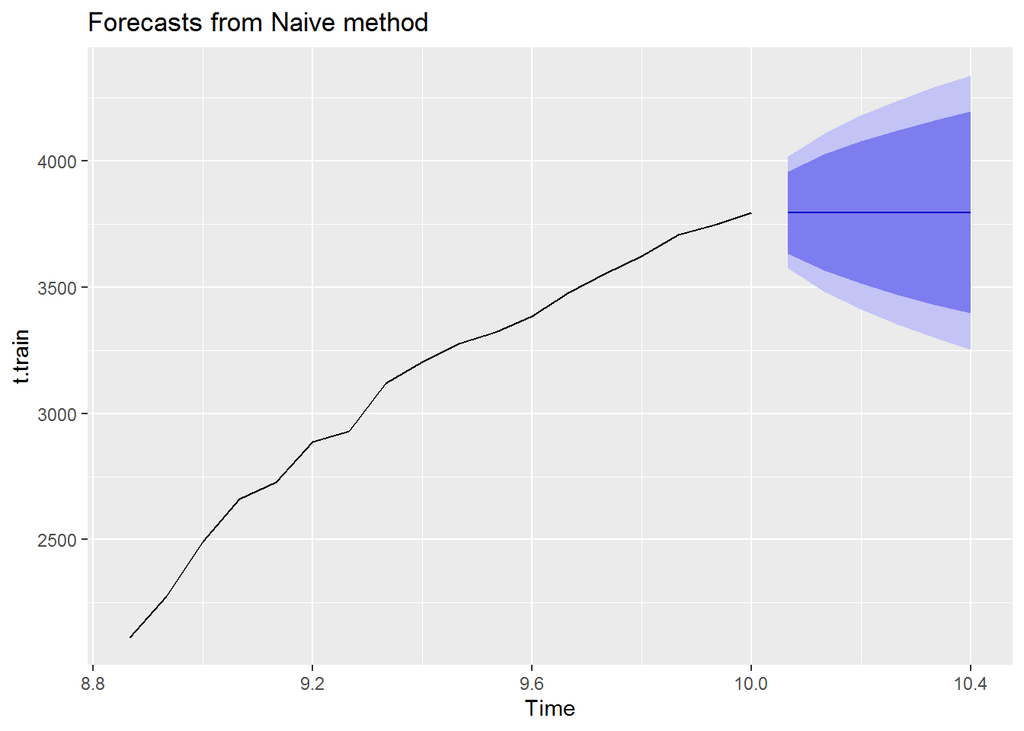

```r
t.naive <- naive(t.train,h=6,level = c(85,95))
autoplot(t.naive)
```

```r
accuracy(t.naive$mean,t.test)
```

```
##           ME     RMSE MAE      MPE     MAPE      ACF1 Theil's U
## Test set 142 160.1662 142 3.572728 3.572728 0.3430737  3.132556
```

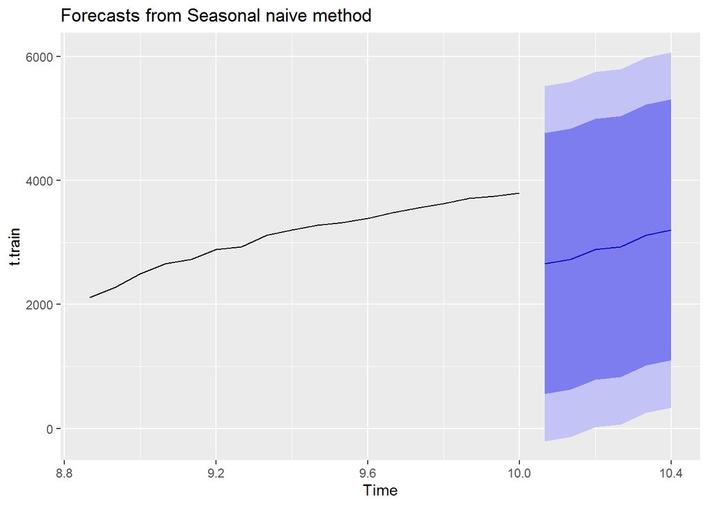

```r
t.snaive <- snaive(t.train,h=6,level = c(85,95))
autoplot(t.snaive)
```

```r
accuracy(t.snaive$mean,t.test)
```

```
##              ME     RMSE    MAE      MPE     MAPE      ACF1 Theil's U
## Test set 1072.4 1076.276 1072.4 27.28798 27.28798 0.2232821   18.6885
```

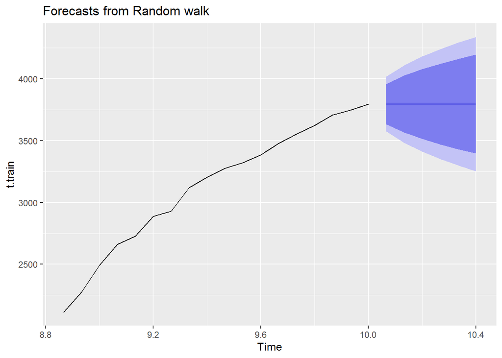

```r
t.rwf <- rwf(t.train,h=6,level = c(85,95))
autoplot(t.rwf)
```

```r
accuracy(t.rwf$mean,t.test)
```

```
##           ME     RMSE MAE      MPE     MAPE      ACF1 Theil's U
## Test set 142 160.1662 142 3.572728 3.572728 0.3430737  3.132556
```

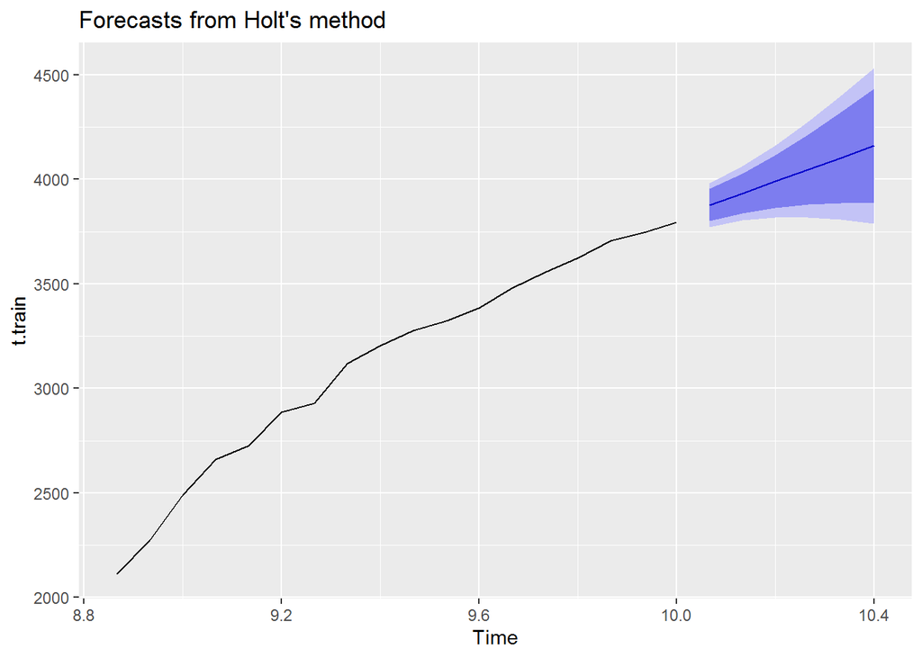

```r
t.holt <- holt(t.train,h=6,level = c(85,95))
autoplot(t.holt)
```

```r
accuracy(t.holt$mean,t.test)
```

```
##                 ME     RMSE      MAE       MPE     MAPE       ACF1
## Test set -53.33554 54.49967 53.33554 -1.352546 1.352546 0.07912334
##          Theil's U
## Test set  1.002301
```

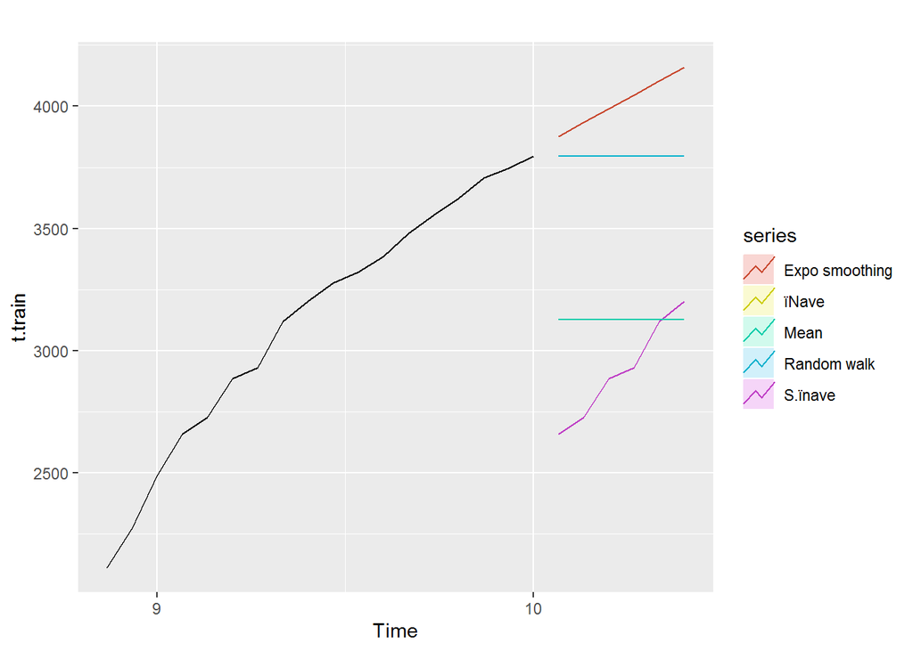

```r
autoplot(t.train) +
  autolayer(snaive(t.train, h=6),series="S.ïnave", PI=F) +  ##Mean
  autolayer(naive(t.train, h=6),series="ïNave", PI=F) +  ##Naive
  autolayer(meanf(t.train, h=6),series="Mean", PI=F) +
  autolayer(rwf(t.train, h=6),series="Random walk", PI=F) +
  autolayer(holt(t.train, h=6),series="Expo smoothing", PI=F)
```

From the experiment we can see that the exponential smoothing method have the most accuracy.

#g classification

```r
ctree.result <- predict(AS.ctree,newdata = Attribute_DataSet2.Test.cha[2:13])
table(ctree.result,Attribute_DataSet2.Test.cha[,14])
```

```
##
## ctree.result  0  1
##            0 29 15
##            1  1  5
```

forecasting

```r
Attribute_DataSet2.Test.cha <- as.data.table(Attribute_DataSet2.Test.cha)
Att.Sale.test <- Attribute_DataSet2.Test.cha[Dress_Sales2.DT.clean,on=.(Dress_ID==Dress_ID)]
Att.Sale.test <- na.omit(Att.Sale.test)

Att.Sale.test <- as.data.table(Att.Sale.test)
Att.Sale.test$ X12.9.2013 <- as.numeric(as.character(Att.Sale.test$ X12.9.2013))
Att.Sale.test$ X14.9.2013 <- as.numeric(as.character(Att.Sale.test$ X14.9.2013))
Att.Sale.test$ X16.9.2013 <- as.numeric(as.character(Att.Sale.test$ X16.9.2013))
Att.Sale.test$ X18.9.2013 <- as.numeric(as.character(Att.Sale.test$ X18.9.2013))
Att.Sale.test$ X20.9.2013 <- as.numeric(as.character(Att.Sale.test$ X20.9.2013))
Att.Sale.test$ X22.9.2013 <- as.numeric(as.character(Att.Sale.test$ X22.9.2013))

t <- ts(t(Att.Sale.test[2,15:37]), frequency = 15, start = c(8, 14))
t.train <- window(t,start=8,end=10)
t.test <- window(t,start=10,end=11)
```

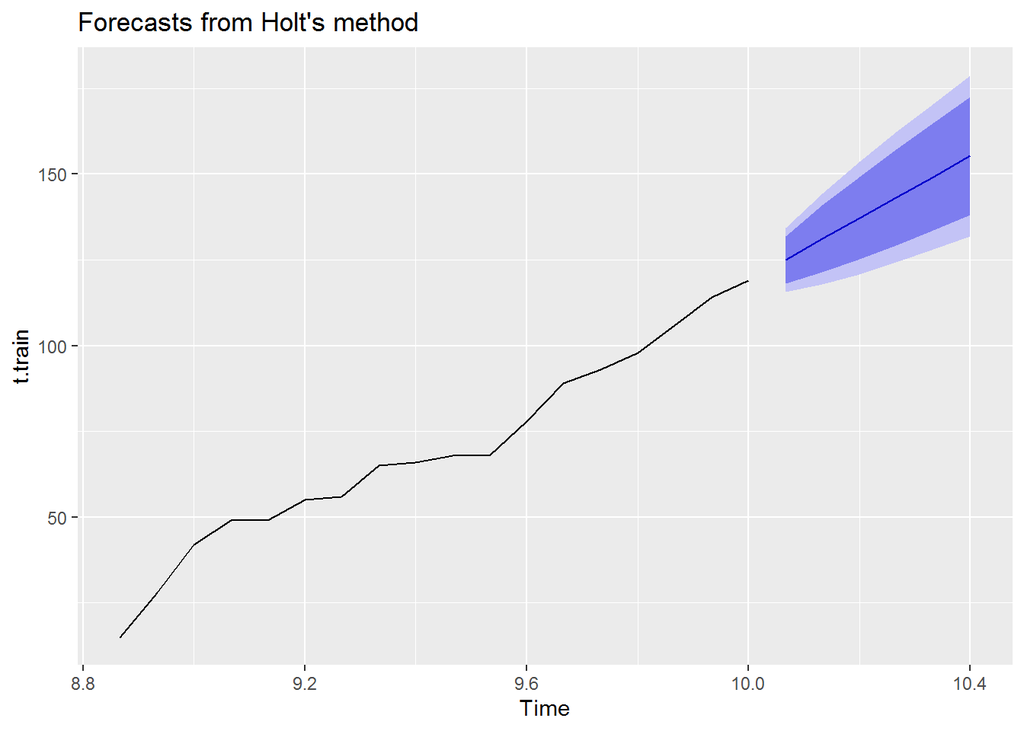

```r
t.holt <- holt(t.train,h=6,level = c(85,95))
autoplot(t.holt)
```

```r
accuracy(t.holt$mean,t.test)
```

```
##                 ME     RMSE      MAE       MPE     MAPE      ACF1
## Test set -6.570072 7.669689 6.570072 -4.933131 4.933131 0.4650898
##          Theil's U
## Test set   2.30433
```

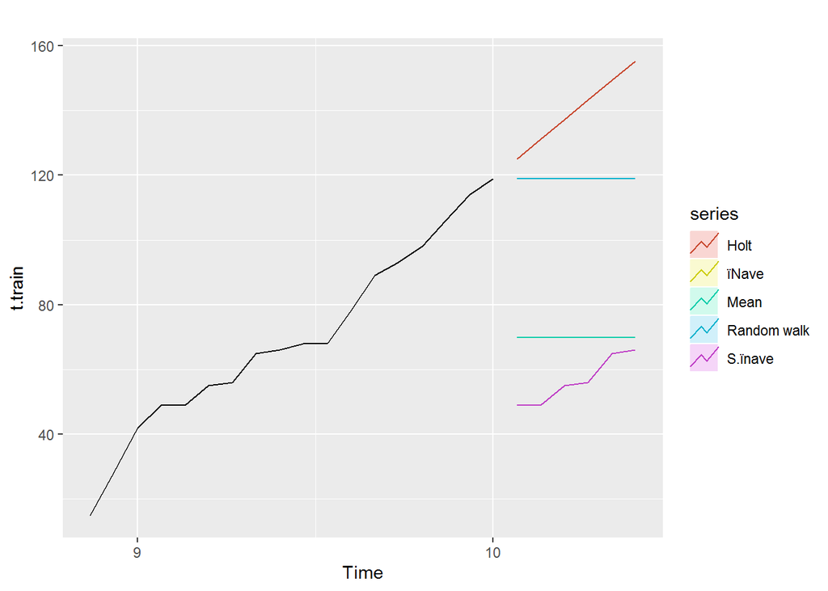

```r
autoplot(t.train) +
  autolayer(snaive(t.train, h=6),series="S.ïnave", PI=F) +  ##Mean
  autolayer(naive(t.train, h=6),series="ïNave", PI=F) +  ##Naive
  autolayer(meanf(t.train, h=6),series="Mean", PI=F) +
  autolayer(rwf(t.train, h=6),series="Random walk", PI=F) +
  autolayer(holt(t.train, h=6),series="Holt", PI=F)
```